# Results of Pilot coding exercise: 5 LIDD coders

## Overview

This report presents the results of the LIDD pilot coding exercise. The aim is to evaluate the policy typology presented in the two 2020 articles by Silagadze & Gherghina (hereafter SG).

The following bullet points include some of the main parameters of the coding analysis as presented below.

- 32 referendum events were coded (these were randomly selected so that 1 event was chosen per country)
- 5 LIDD coders submitted their pilot coding (the coders are referred to as coders, 1 to 5)
- The codes from SG are referred to as “coder 0”
- For the 5 LIDD coders I have calculated a “majority vote”. For most referendum events the LIDD coders agreed, but where there is disagreement a majority vote was taken. It takes the following form: If coder 1, 2, 4 and 5 assigned X to a referendum, but coder 3 assigned Y, then X is taken as the majority vote (i.e., X has 4 votes vs. Y’s 1 vote).
- Two measures of reliability are used. An (i) “agreement” measure and an (ii) intercoder reliability measure.
- The “agreement” measure. Agreement between a pair of coders is quite easy to understand. If coders 1 and 2 coded 100 referendums and agreed (assigned the same codes) to 60 referendums, then the level of “agreement” would be 60% (disagreement would be 40%).
- The “intercoder reliability measure.” The methodological literature uses a metric called “intercoder reliability” to measure the degree of agreement between coders rating items (referendum topics in our case). This measure is a bit more sophisticated and takes into account things like the level of agreement that could be achieved by chance (random answering). It’s called the Kappa intercoder reliability measure.
- The Kappa score can vary from `-1 to 1`. It was suggested by the author of the Kappa measure that the score could be interpreted as follows: values less than `0` indicate no agreement; and `0.01–0.20` as none to slight; `0.21–0.40` as fair; `0.41–0.60` as moderate; `0.61–0.80` as substantial; and `0.81–1.00` as almost perfect agreement.

## Agreement among LIDD coders

The table below presents the two measures across the pairs of LIDD coders. With five LIDD coders, we have 10 possible pairwise comparisons. The Kappa value in the last row is the measure of intercoder reliability among the 5 LIDD coders, which at .78 is good.

| LIDD coder pair | Agreement % | Kappa (intercoder reliability) |
| --- | --- | --- |
| c1 vs c2 | 81.250 | 0.77 |
| c1 vs c3 | 81.250 | 0.76 |
| c2 vs c3 | 81.250 | 0.77 |
| c1 vs c4 | 84.375 | 0.81 |
| c2 vs c4 | 90.625 | 0.89 |
| c3 vs c4 | 78.125 | 0.73 |
| c1 vs c5 | 84.375 | 0.81 |
| c2 vs c5 | 78.125 | 0.74 |
| c3 vs c5 | 78.125 | 0.73 |
| c4 vs c5 | 84.375 | 0.81 |
| All | 65.625 | 0.78 |

## LIDD majority vote vs. SG code

The results below is for the majority vote extracted from the 5 LIDD coders compared to the SG code. As can be seen, the level of inter coder reliability is extremely high when taking a LIDD majority vote. In fact, there is only 1 items where the codes are divergent (see further below)

| Agreement % | Kappa (intercoder reliability) |
| --- | --- |
| 96.875 | 0.96 |

## Exploring differences among LIDD coders

The analysis above shows a high degree of convergence among LIDD coders, an intercoder reliability of .78. And an extremely high intercoder reliability when a majority vote is used to compare LIDD vs SG.

We can visualise convergence on a referendum code in a plot. In the plots below we include the LIDD 5 coders (coders 1 to 5) plus the SG codes (called coder 0).

The plot below is an example of complete converge. The horizontal axis shows the ‘Code assigned’ while the vertical axis is a count measure of how many codes were assigned. The title refers to the event coded (in the example below one of the EU membership referendums). Thus, in the plot below the exact same code was assigned by the 5 coders (plus SG code) to the EU membership referendum. This is obviously an easy coding case since EU membership referendums were specifically defined.

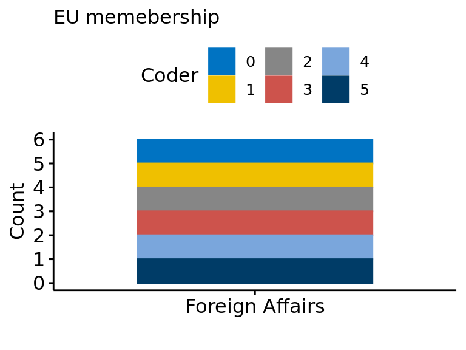

Most of the referendum events (21 of them) would look like the graph above.

Nonetheless, it can be very useful to examine divergences. Here we can look at differences among LIDD coders. The table below lists the items with at least one divergent coding.

| id | sg_title |
| --- | --- |
| 112 | On accepting bailout conditions of EC, ECB and IMF |
| 129 | Amendment of the Icesave compensation agreement with Great Britain and the Netherlands |
| 138 | Children’s rights |
| 224 | Dissolution of Parliament by popular initiative |
| 239 | Constructing a country road in Schaan |
| 330 | Impeachment of President Basescu |
| 351 | Revoking the lowering of the qualified majority necessary for selling public property |
| 395 | Arbitration procedure for defining the border with Croatia |
| 413 | Introducing the Euro as national currency |
| 415 | Constitutional reform |
| 95 | Female succession to throne |

Below we plot those divergent referendums. As noted above it’s actually not that many. Using a majority vote for LIDD coders would have ironed out virtually all divergences when doing a pairwise LIDD comparison with coder 0 (the SG codes).

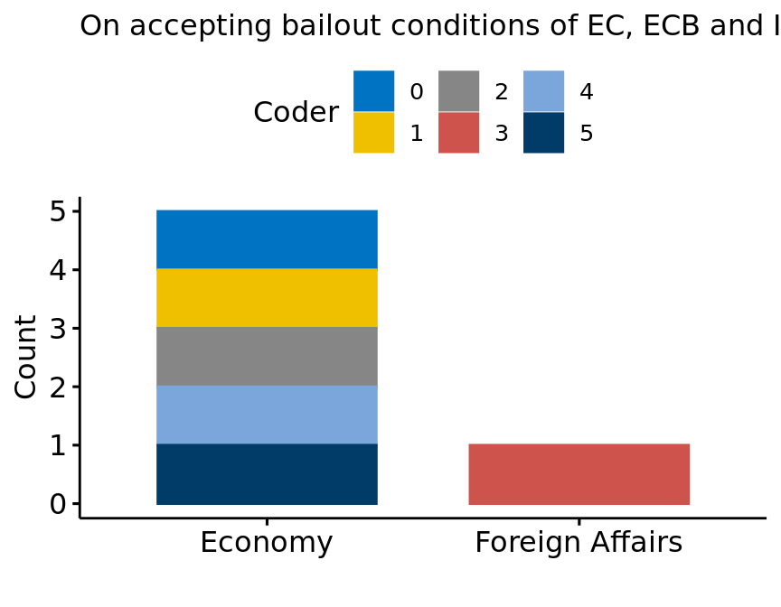

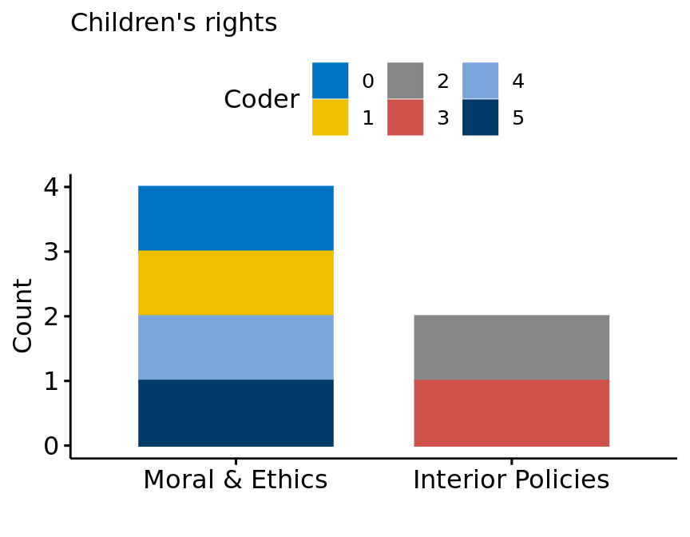

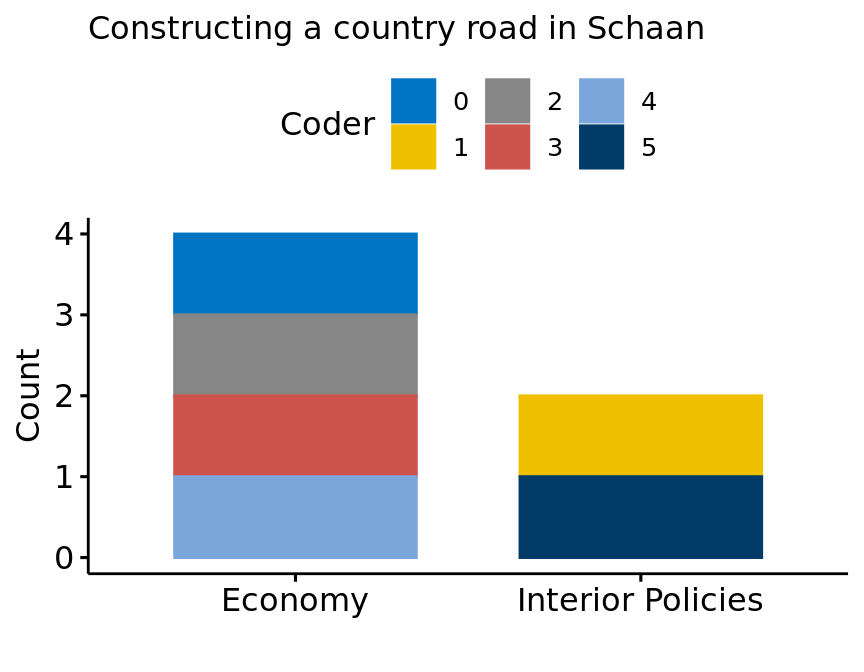

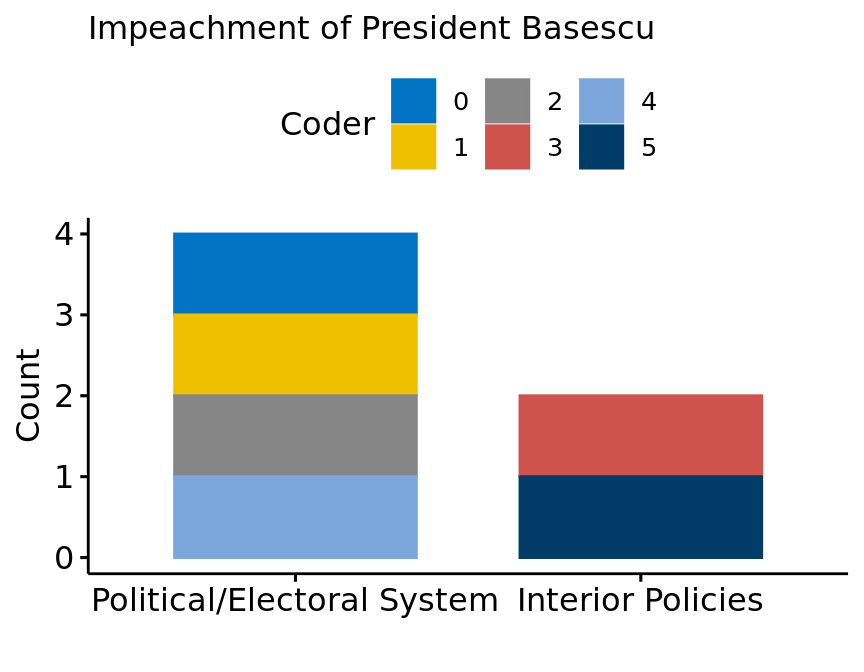

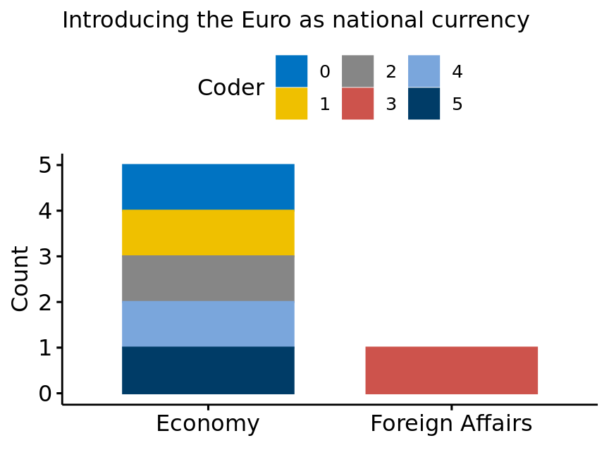

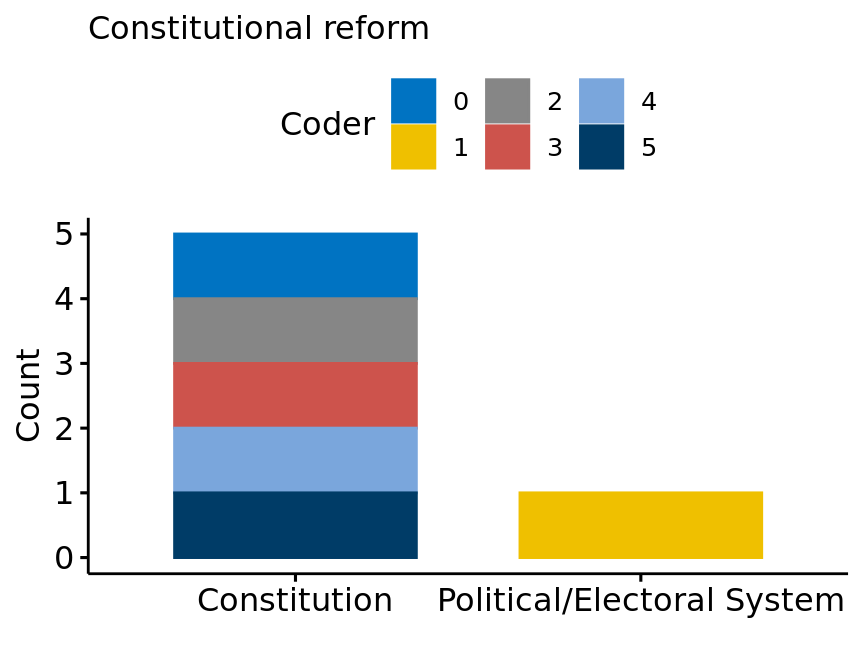

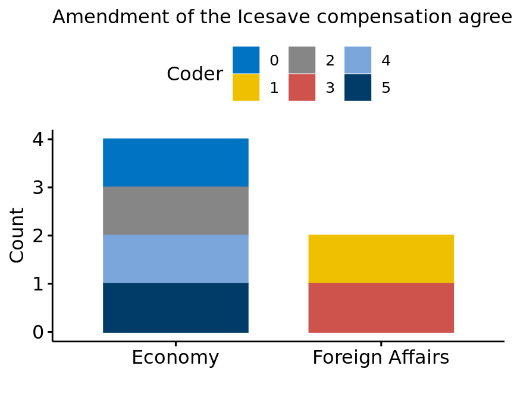

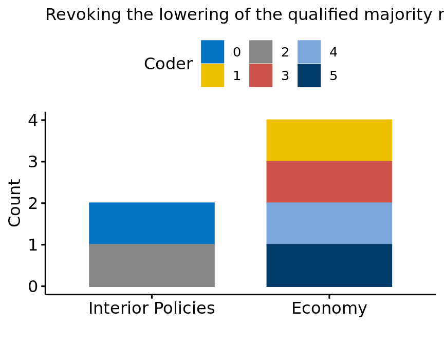

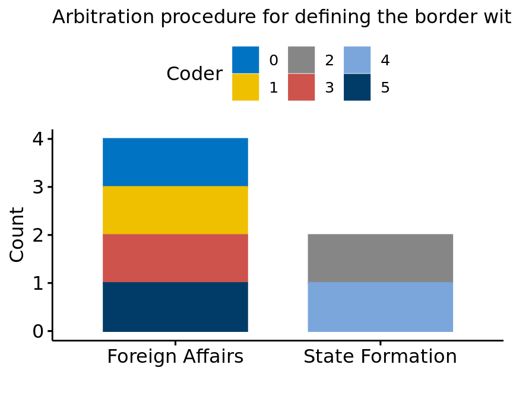

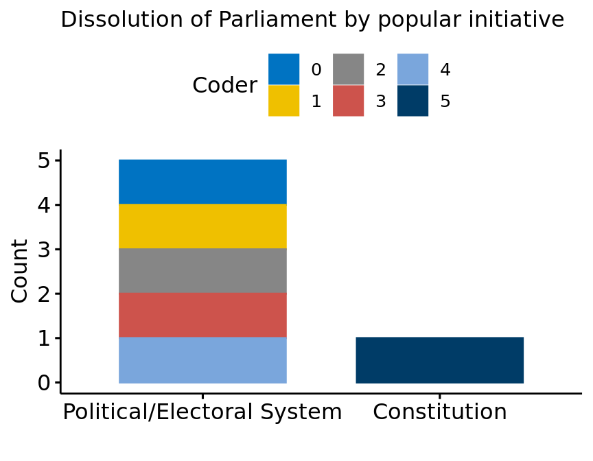

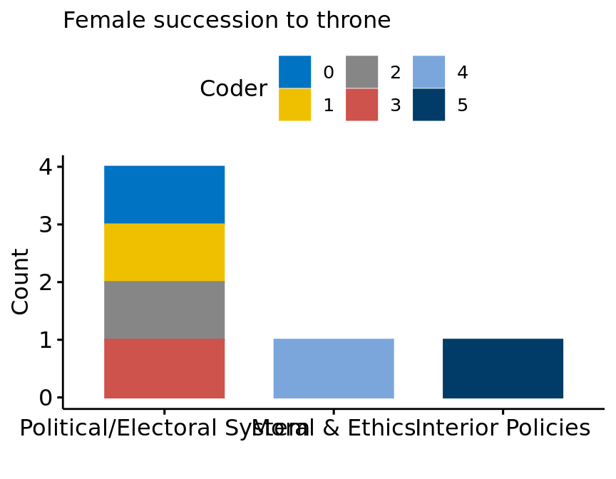

## Summary

There is good convergence between coders with intercoder reliability values near the 0.8 region (which is high for social sciences) for LIDD coders. Furthermore, the intercoder reliability between SG codes and the LIDD majority vote is extremely high, only 1 referendum divergence. Admittedly, we only included 32 referendums … but I don’t think adding more would necessarily have altered the main results. Perhaps, the sampled referendums were all easy … again I don’t think that is the case.

In short, I think them main finding from the pilot is that we can use the SG codes for all the referendums for which we have corresponding data. Here we have a potential issue since there are some c2d referendum events I could not find in the SG data. So these “missing” events would need to be coded (I need to do further checking on this to see the scale of the problem).

Having coded the referendums with no real definitions from SG or coding instructions the results are better than what I expected. We could no doubt improve coding reliability by providing clearer instructions. There is a need to give guidelines on what to do when there is policy overlap. This is probably the most urgent task, to upgrade the definitions in the table below. At that point it could make sense to repeat the coding exercise for a random sample of Swiss cases.

#### Definitions

| Code_ID | Category | Definition |
| --- | --- | --- |
| 1 | Constitution | All referendums on adoption of a new constitution or on approval of constitutional reform regarding major changes. We cluster all other cases where certain constitutional issues were put on ballot acc… |
| 2 | State Formation | State formation includes all referendums on independence; referendums on whether an entity should remain part of a state or become part of another state; referendums on a new territorial composition o… |
| 3 | Political/Electoral System | The referendums on the political system refer to popular votes about the form of government; distribution of power; the introduction or abolishment of new political institutions, and electoral system … |
| 4 | Interior Policies | The interior policy referendums include popular votes on basic rights; laws on citizenship; particular regulations; legal framework (e.g. land law reform); or administrative reorganization. |
| 5 | Foreign Affairs | The foreign affairs category includes all topics of interstate relations, such as: border/territory issues; international arrangements; international/supranational collaboration (e.g. European integra… |
| 6 | Economy | The economy category brings together the issues that are related to economic or financial measures; distribution of resources; ownership issues; public expenses. |
| 7 | Environment | The environment category includes referendums on nuclear plants, general policies concerning the environment. |
| 8 | Health | Health policies refer to specific issues or to general issues about the healthcare system. |
| 9 | Education | The education policies refer to both higher education and school policies. |
| 10 | Moral & Ethics | The relatively broad category of family, ethics and moral issues includes referendums on same-sex marriage, divorce, abortion, the death penalty and other moral issues. |
| 11 | Labour & Social | The labour and social issues include referendums on labour regulations, pensions, trade unions, social policies. |
| 12 | Media | The media category includes all referendums on broadcasting rights and further regulations related to media landscape. |

## Annex: LIDD coder comments

### Differences between LIDD and SG

It turns out that when using a LIDD majority vote there was only disagreement on one item, which is shown below:

| id | sg_title | coder0 | Lidd Majority vote |
| --- | --- | --- | --- |
| 351 | Revoking the lowering of the qualified majority necessary for selling public property | Interior Policies | Economy |

### Comments from LIDD coders

Below are some of the comments collected from the 5 LIDD codings. Only 3 coders provided comments (not on all items) and these are listed in the table below.

| id | sg_title | commentsZ | commentsX | commentsY |
| --- | --- | --- | --- | --- |
| 112 | On accepting bailout conditions of EC, ECB and IMF | Evidently, could also be on Foreign affairs. However, economy trumps this in my view | This one is difficult to classify between foreign affairs and economy. | NA |
| 129 | Amendment of the Icesave compensation agreement with Great Britain and the Netherlands | Overlap with the Economy | NA | NA |
| 138 | Children’s rights | No information on this referendum; though it could classed as a social issue | NA | Don’t think the category “morals & ethics” makes sense, i.e. that this could be coded consistently |
| 239 | Constructing a country road in Schaan | NA | These type of single projects are not easy to classify under their system. It might also be classified as interior policy, but then I think the interior policy category would be too wide, covering eve… | A category such as “infrastructure” might be needed |
| 320 | Legalizing abortion | NA | NA | As above: I don’t think we should keep this category; if anything, rename it as “family policy” or something like that |
| 330 | Impeachment of President Basescu | NA | This a recall that we might not even have to include in our database. | NA |
| 351 | Revoking the lowering of the qualified majority necessary for selling public property | Economy and Interior policies overlap | This is again between economy and interior policy | NA |
| 413 | Introducing the Euro as national currency | Evidently, could also be on Foreign affairs. However, economy trumps this in my view | NA | NA |
| 415 | Constitutional reform | All the main constitutional changes were related to politics/electoral system | NA | NA |
| 95 | Female succession to throne | Difficult to assign | NA | NA |